# PRA 2: Neteja, validació i anàlisi de les dades

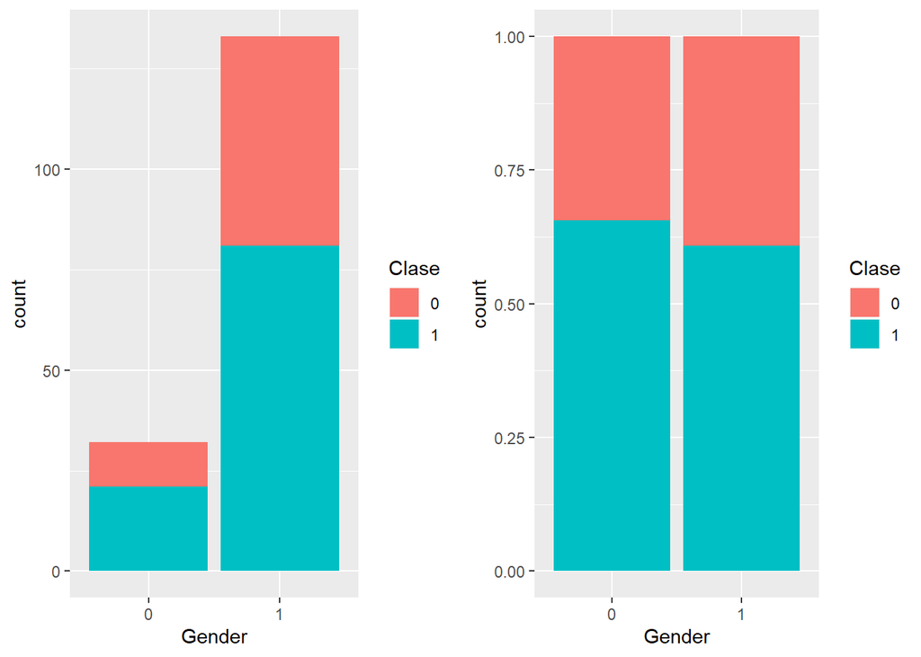

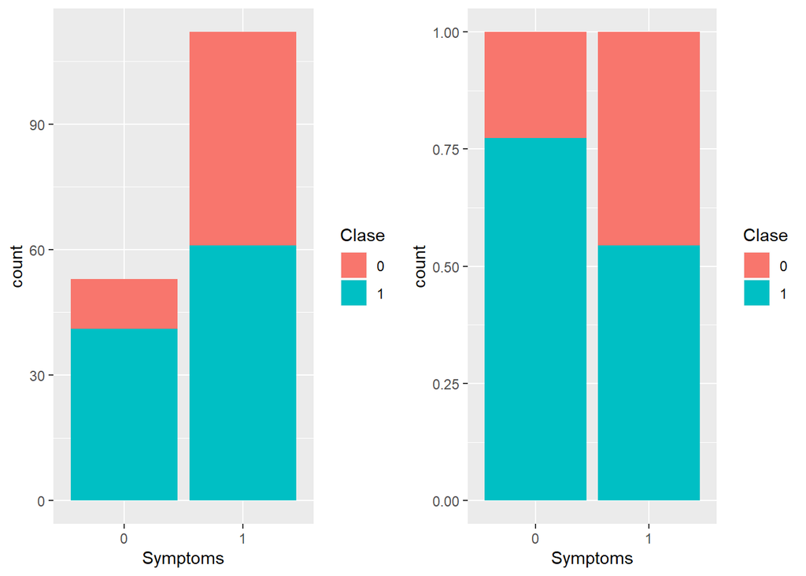

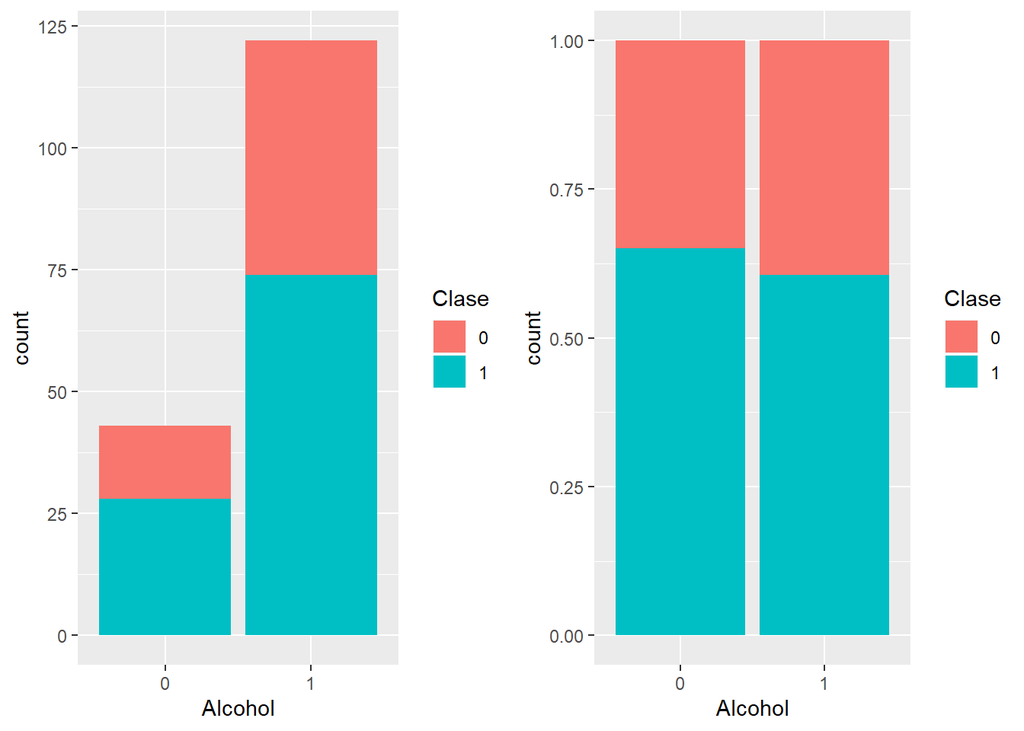

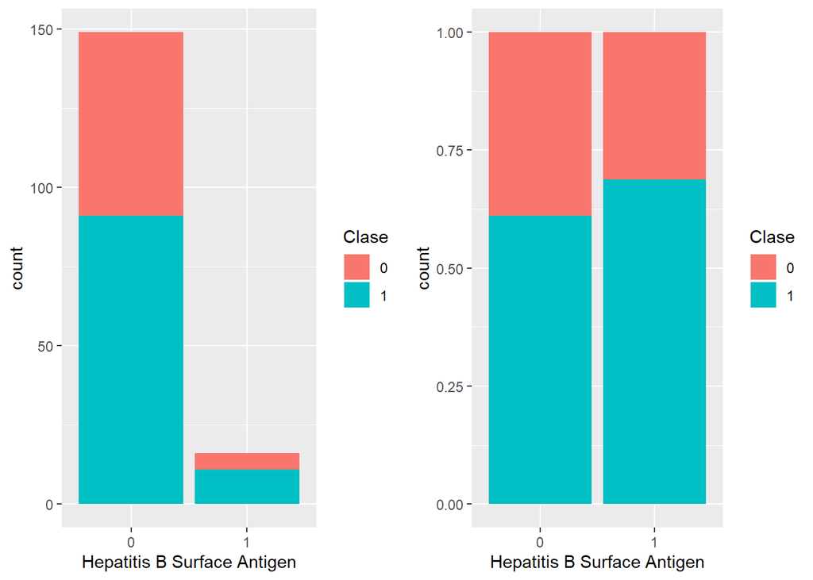

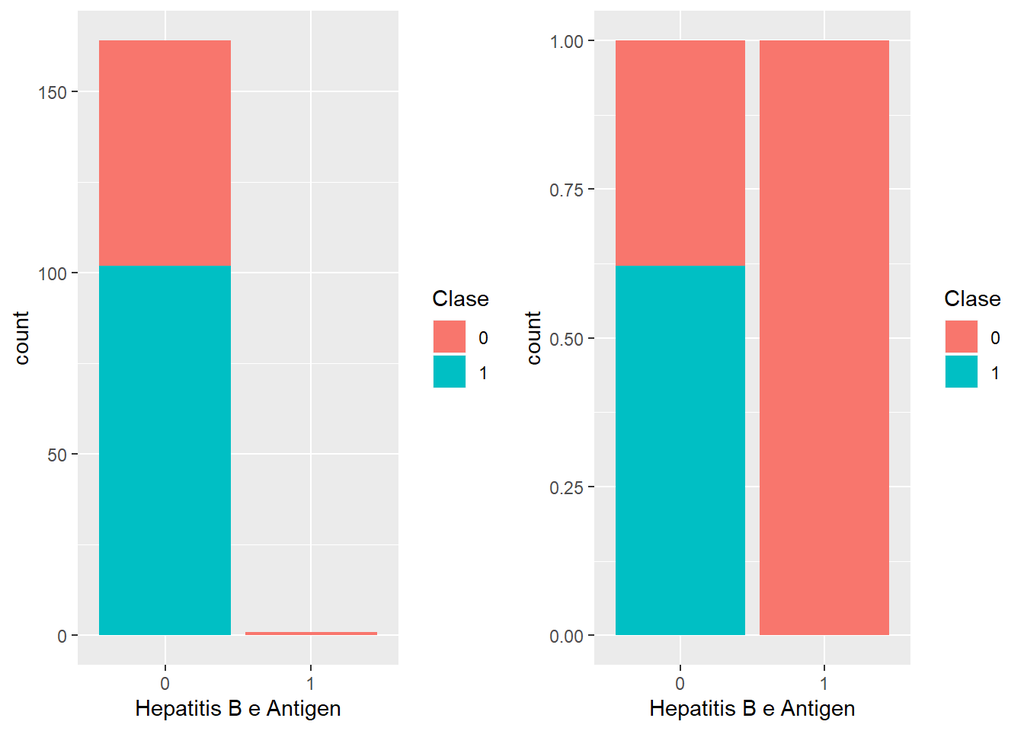

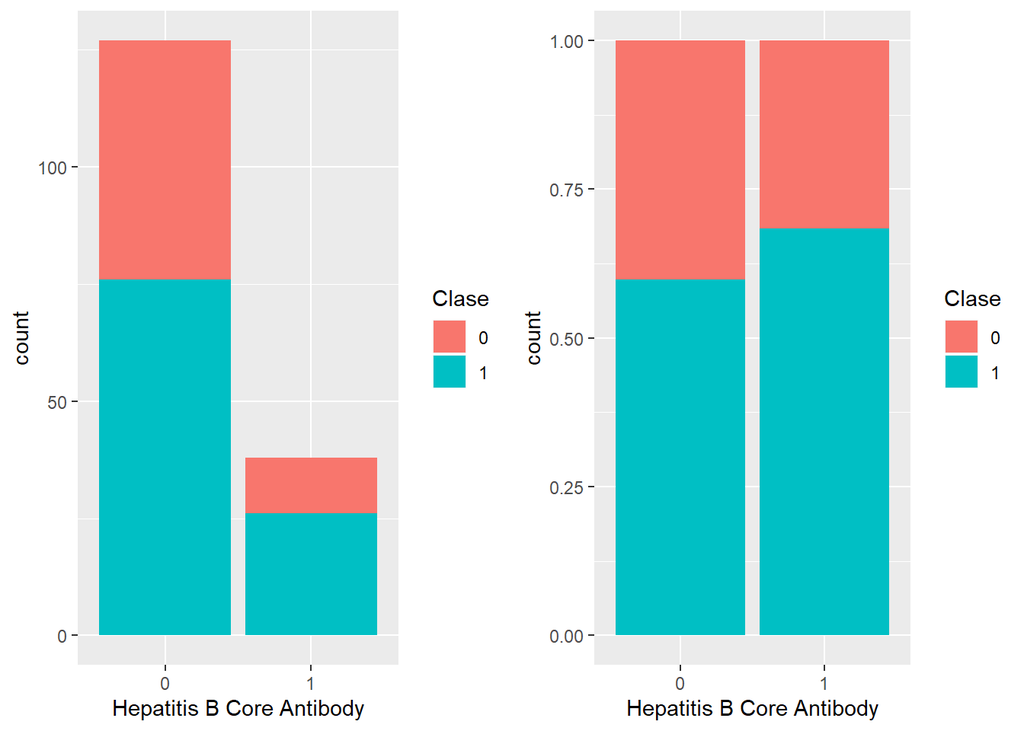

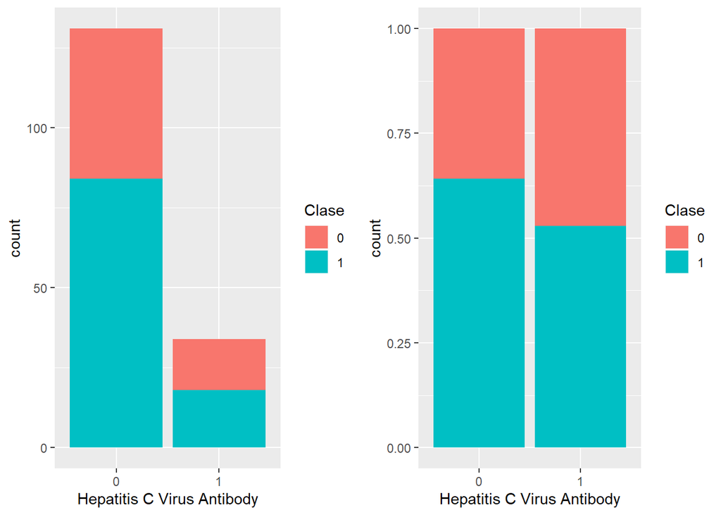

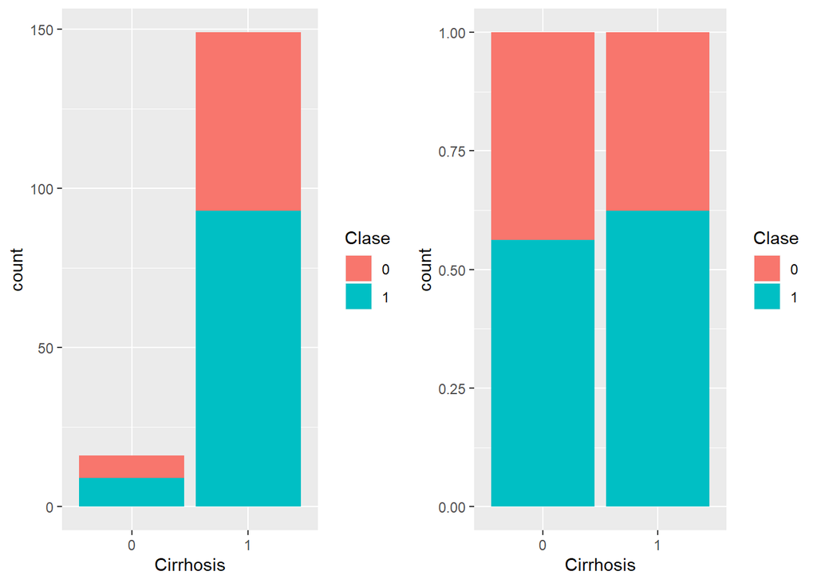

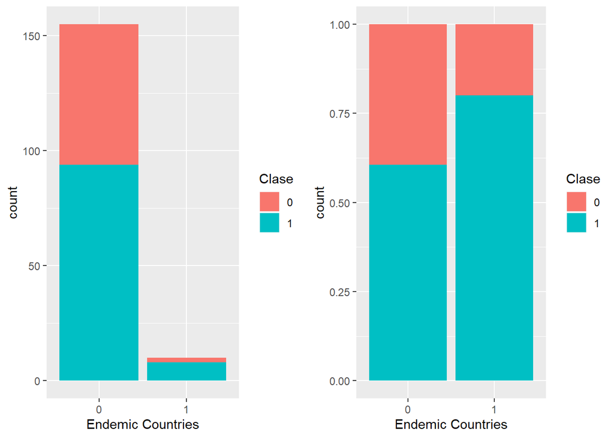

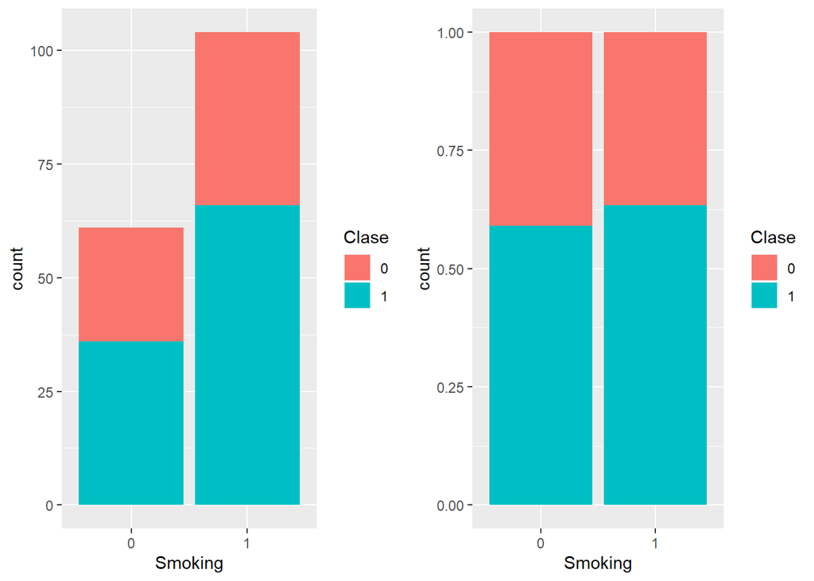

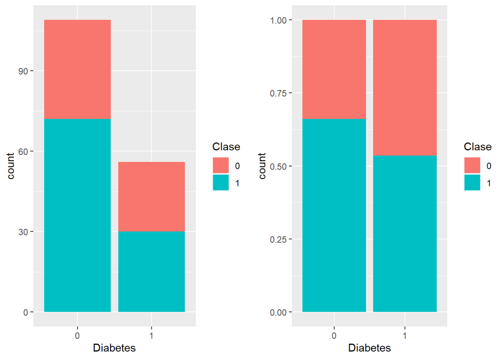

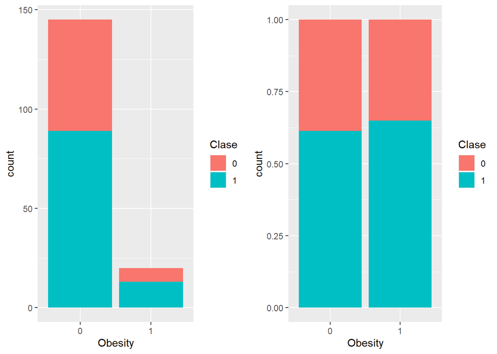

[14 more figures not shown]

```r
# Distribució variables quantitatives
hcc_factorT<-c(1:23,27:29)


for (i in hcc_factorT)
  {
  a1<-ggplot(hcc, aes(x=hcc[,i],fill=hcc$`Class Attribute`))+
        xlab(names(hcc)[i])+
        labs(fill="Clase") +
        geom_bar()
  a2<-ggplot(hcc, aes(x=hcc[,i],fill=hcc$`Class Attribute`))+
        xlab(names(hcc)[i])+
        labs(fill="Clase") +
        geom_bar(position = "fill")

  grid.arrange(a1,a2,nrow=1)
}
```

### 2.4.1 Comprobació de la normalitat

```r
library(nortest)
alpha = 0.05
col.names = colnames(hcc)
for (i in 1:ncol(hcc)) {
  if (i == 1) cat("Variables que no segueixen una distribució normal:\n")
  if (is.integer(hcc[,i]) | is.numeric(hcc[,i])) {
    p_val = ad.test(hcc[,i])$p.value
    if (p_val < alpha) {
      cat(col.names[i])
      # Format output
      if (i < ncol(hcc) - 1) cat(", ")
      if (i %% 3 == 0) cat("\n")
    }
  }
}
```

```
## Variables que no segueixen una distribució normal:
## Age at diagnosis,
## Grams of Alcohol per day, Packs of cigarets per year, International Normalised Ratio,
## log_Alpha-Fetoprotein (ng/mL), Leukocytes(G/L), Platelets, Albumin (mg/dL),
## log_Total Bilirubin(mg/dL), log_Alanine transaminase (U/L), log_Aspartate transaminase (U/L),
## log_Alkaline phosphatase (U/L), log_Total Proteins (g/dL),
## log_Creatinine (mg/dL), Number of Nodules, Major dimension of nodule (cm),
## log_Direct Bilirubin (mg/dL), Iron, Oxygen Saturation (%),
## Ferritin (ng/mL)
```

Com es pot veure, hi ha moltes variables numériques que es distancien significativament de la distribució normal, per el que s’usaran test no paramétrics (Mann–Whitney–Wilcoxon) per la comparativa en relació a la supervivència.

## 2.5 Proves estadístiques

### 2.5.1 Comparació entre grups de la classe

Per tal de valorar quines variables es comporten diferents entre en que sobreviuen i els que no, es realitzarà els diferents test estadístics:

- Per les variables quantititatives, donada les seves distribucións majoritària diferent a la normalitat, es realitzara el test no paramètric de Mann–Whitney–Wilcoxon
- Per les variables qualitatives es realitzarà un test chi-quadrat.

```r
testSig <- tibble()


cat("Variables categóriques amb p<0.10 entre la classe:\n")
```

```
## Variables categóriques amb p<0.10 entre la classe:
```

```r
for (i in hcc_factorT) {
  tabla=table(hcc[,i], hcc$`Class Attribute`)
  chi=chisq.test(tabla)
  if (chi$p.value<0.1){
    cat(names(hcc)[i],":\n")
    cat("p=",chi$p.value, "\n")
    testSig <- testSig %>% bind_rows(c(Clase = i, Name=names(hcc[i]),Categorica="1",p_value = chi$p.value))
    }
}
```

```
## Symptoms :
## p= 0.007933578
## Portal Vein Thrombosis :
## p= 0.008776766
## Liver Metastasis :
## p= 0.002624464
## Performance Status :
## p= 3.254868e-05
## Encephalopathy degree :
## p= 0.03543194
## Ascites degree :
## p= 0.002912547
```

```r
cat("\n")
```

```r
cat("Variables numériques amb p<0.10 entre la classe:\n")
```

```
## Variables numériques amb p<0.10 entre la classe:
```

```r
for (i in hcc_num) {
  wil=wilcox.test(hcc[hcc$`Class Attribute`==1,i],hcc[hcc$`Class Attribute`==0,i], mu = 0,paired = FALSE, conf.int = 0.95)

  if (wil$p.value<0.1){
    cat(names(hcc)[i],":\n")
    cat("p=",wil$p.value, "\n")
    testSig <- testSig %>% bind_rows(c(Clase = i, Name=names(hcc[i]),Categorica="0",p_value = wil$p.value))
    }
  }
```

```
## Age at diagnosis :
## p= 0.03568324
## International Normalised Ratio :
## p= 0.03140037
## log_Alpha-Fetoprotein (ng/mL) :
## p= 2.831168e-06
## Haemoglobin (g/dL) :
## p= 5.968093e-05
## Platelets :
## p= 0.03501771
## Albumin (mg/dL) :
## p= 0.000223525
## log_Total Bilirubin(mg/dL) :
## p= 0.03695266
## log_Aspartate transaminase (U/L) :
## p= 0.001587891
## log_Gamma glutamyl transferase (U/L) :
## p= 0.01862733
## log_Alkaline phosphatase (U/L) :
## p= 6.898549e-07
## log_Creatinine (mg/dL) :
## p= 0.09840758
## Major dimension of nodule (cm) :
## p= 0.03803416
## log_Direct Bilirubin (mg/dL) :
## p= 0.003341791
## Iron :
## p= 0.003808222
## Ferritin (ng/mL) :
## p= 0.007306848
```

Aquestes variables seran les que es seleccionarà per a la creació d’un model de regressió logística, però abans, valorarem les correlacions entre elles per tal de seleccionar variables que estiguin poc relacionades entre elles.

### 2.5.2 Correlació entre les variables seleccionades

Amb respecte a la corrrelació entre les variables seleccionades, veiem la seva matriu de correlacions. Donada l’existència de variables categóriques, aquestes es consideradan numériques i usarem la correlació no paramétrica de Spearman per a la seva valoració. Previament es normalitzaran totes les variables quantitatives.

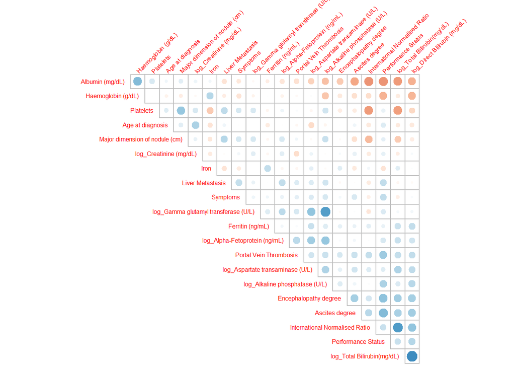

```r
# Correlación variables independientes.
library(corrplot)
hcc_norm<- hcc
atr<-names(hcc)
hcc_norm[,hcc_num]<-scale(hcc_norm[,hcc_num])

hcc2<-as.data.frame(lapply(hcc_norm,as.numeric))
#names(hcc2)<-hcc_header_cortos

#sjp.corr(hcc2, corr.method = "spearman", sort.corr = FALSE, wrap.labels = 15, axis.labels=hcc_header2, decimals = 1, show.values = FALSE)

#corrplot::corrplot(hcc_cor[1:10,, drop=FALSE], cl.pos='n',tl.srt = 45, tl.cex = 0.5)
names(hcc2)<-atr

hcc_cor<-cor(hcc2[,testSig$Name], method = "spearman")
corrplot(hcc_cor, cl.pos='n',tl.srt = 45, tl.cex = 0.5, type="upper",method = "circle", order="FPC", diag=FALSE)
```